# Digit Recognition

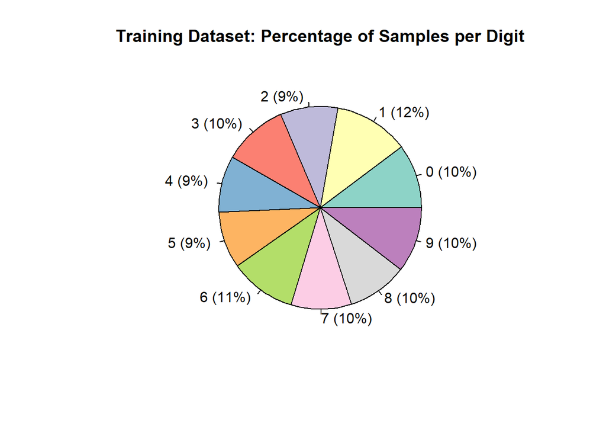

```r
colorPlot <- colorRampPalette(brewer.pal(10, "Set3"))
percent <- round(labelTable/sum(labelTable)*100)
labels <- paste0(row.names(labelTable), " (",percent,"%) ")
pie(labelTable, labels = labels, col = colorPlot(10), main = "Training Dataset: Percentage of Samples per Digit")
```

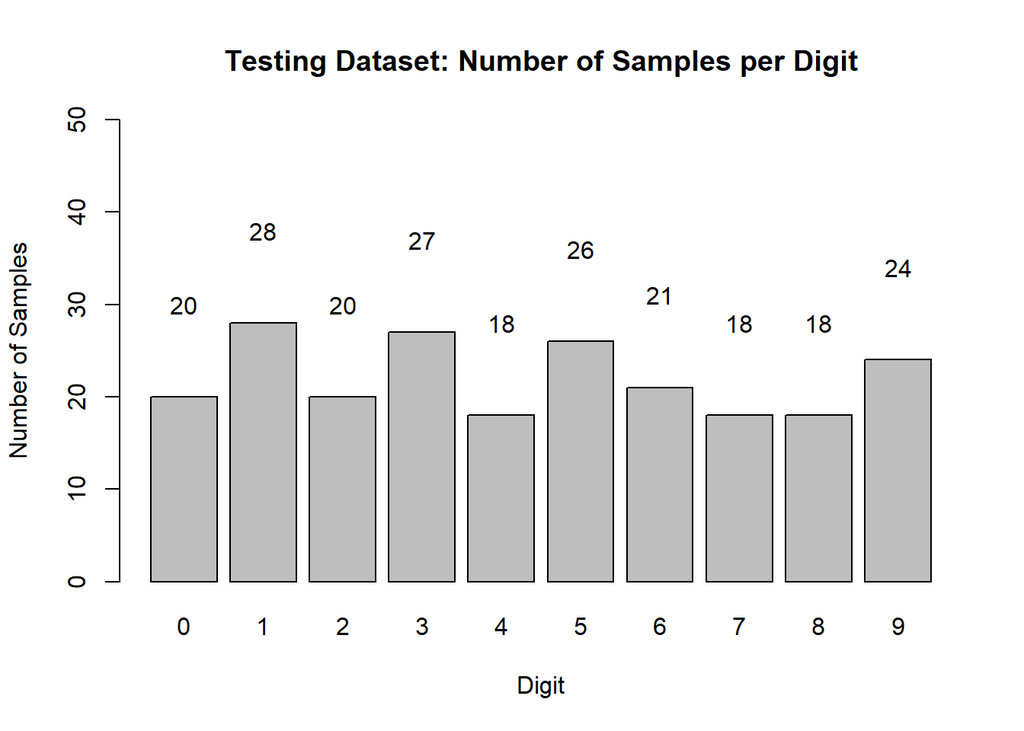

```r
labelTable <- table(data_test$label)
barPlot <- plot(data_test$label, main = "Testing Dataset: Number of Samples per Digit", ylim = c(0, 50), xlab = "Digit", ylab = "Number of Samples")
text(x = barPlot, y = labelTable+10, labels = labelTable)
```

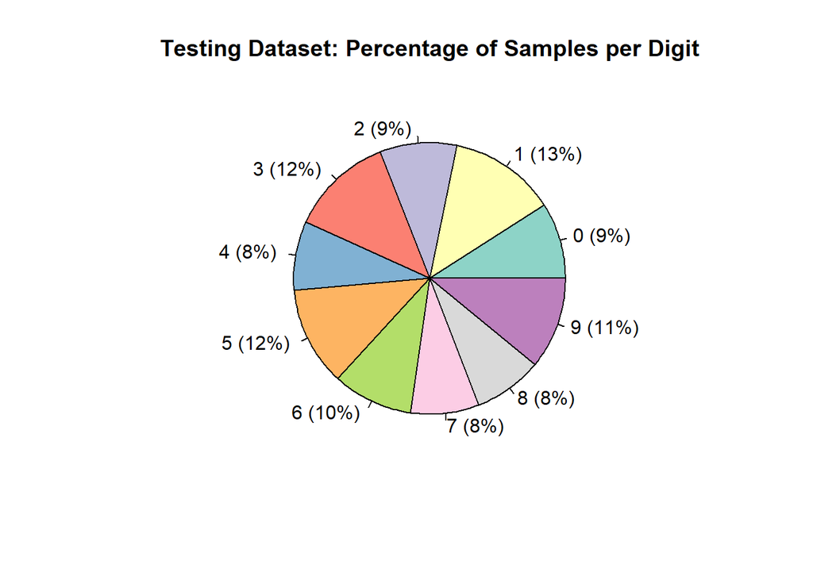

```r
colorPlot <- colorRampPalette(brewer.pal(10, "Set3"))
percent <- round(labelTable/sum(labelTable)*100)
labels <- paste0(row.names(labelTable), " (",percent,"%) ")
pie(labelTable, labels = labels, col = colorPlot(10), main = "Testing Dataset: Percentage of Samples per Digit")
```

In order to achieve higher accuracy in both models, the columns with near zero variance and all-zero values are removed from both the training and testing datasets. Since the columns with near zero variance were removed, additional preprocessing is then done to scale and center the training data variables. The scaling and centering preprocessing needed for the training and testing datasets is defined in the “pre_process” variable.

```r
data_NZV <- nearZeroVar(data_train, saveMetrics = TRUE)
columns_NZV <- rownames(data_NZV)[data_NZV$nzv == TRUE]
data_train <- data_train[,!names(data_train) %in% columns_NZV]
data_test <- data_test[,!names(data_test) %in% columns_NZV]
pre_process <- preProcess(data_train, method = c("scale", "center"))
pre_process
```

```
## Created from 1122 samples and 290 variables
##
## Pre-processing:
##   - centered (289)
##   - ignored (1)
##   - scaled (289)
```

## Naive Bayes Method

In addition to the general data preprocessing done for both models, the training and testing datasets are further preprocessed for the Naive Bayes algorithm by the ‘predict()’ function. This function takes as input both the variable containing the preprocessing information (variable ‘pre_process’), as well as the dataset that should be preprocessed. Both the training and testing datasets are scaled and centered via this function.

```r
data_train1 <- predict(pre_process, newdata = data_train)
data_test1 <- predict(pre_process, newdata = data_test)
```

Now that the preprocessing steps are complete, the Naive Bayes model is trained on the training dataset. For comparative purposes with the kNN model, the amount of time taken to train this model is recorded using the method proc.time(). The Naive Bayes model uses the ‘trainControl()’ method as a parameter to indicate that the repeated cross-validation resampling method should be used, with a set of 8 folds repeated 3 times. The ‘tuneGrid’ parameter is also used to train this model, with several Bayesian method tuning values (fL (handles issue of zero probability via add-one smoothing), usekernel(‘FALSE’ estimates normal density function)) used on the data frame. This model typically takes between 0.1-0.2 seconds to complete.

```r
time <- proc.time()
model_naiveBayes <- naiveBayes(data_train1$label ~ ., data = data_train1, trcontrol = trainControl(method = "repeatedcv", number = 8, repeats = 3),tuneGrid = data.frame(fL = 1, usekernel = FALSE, adjust = 1))
proc.time() - time
```

```
##    user  system elapsed
##    0.14    0.00    0.18
```

Now that the Naive Bayes model has been trained, the model is used to predict the target attribute (‘label’) values on the testing dataset. A confusion matrix is then displayed, showing the number of correct and incorrect predictions made for each digit in the dataset. The matrix shows that an accuracy of 84.55% was achieved from using the Naive Bayes model to predict the labels of the testing dataset.

```r
predict_naiveBayes <- predict(model_naiveBayes, newdata = data_test1, type = "class")
confusionMatrix(predict_naiveBayes, data_test1$label)
```

```
## Confusion Matrix and Statistics
##
##           Reference
## Prediction  0  1  2  3  4  5  6  7  8  9
##          0 18  0  0  0  0  0  0  0  0  0
##          1  0 28  0  1  0  1  0  0  2  2
##          2  0  0 17  1  0  0  0  1  0  0
##          3  0  0  1 19  0  1  0  0  1  0
##          4  0  0  1  0 10  0  0  0  0  1
##          5  0  0  0  1  0 23  0  0  1  0
##          6  0  0  1  1  1  0 21  0  0  0
##          7  0  0  0  2  2  0  0 16  0  0
##          8  2  0  0  1  2  1  0  0 14  1
##          9  0  0  0  1  3  0  0  1  0 20
##
## Overall Statistics
##
##                Accuracy : 0.8455
##                  95% CI : (0.7908, 0.8905)
##     No Information Rate : 0.1273
##     P-Value [Acc > NIR] : < 2.2e-16
##
##                   Kappa : 0.8277
##
##  Mcnemar's Test P-Value : NA
##
## Statistics by Class:
##
##                      Class: 0 Class: 1 Class: 2 Class: 3 Class: 4 Class: 5
## Sensitivity           0.90000   1.0000  0.85000  0.70370  0.55556   0.8846
## Specificity           1.00000   0.9688  0.99000  0.98446  0.99010   0.9897
## Pos Pred Value        1.00000   0.8235  0.89474  0.86364  0.83333   0.9200
## Neg Pred Value        0.99010   1.0000  0.98507  0.95960  0.96154   0.9846
## Prevalence            0.09091   0.1273  0.09091  0.12273  0.08182   0.1182
## Detection Rate        0.08182   0.1273  0.07727  0.08636  0.04545   0.1045
## Detection Prevalence  0.08182   0.1545  0.08636  0.10000  0.05455   0.1136
## Balanced Accuracy     0.95000   0.9844  0.92000  0.84408  0.77283   0.9372
##                      Class: 6 Class: 7 Class: 8 Class: 9
## Sensitivity           1.00000  0.88889  0.77778  0.83333
## Specificity           0.98492  0.98020  0.96535  0.97449
## Pos Pred Value        0.87500  0.80000  0.66667  0.80000
## Neg Pred Value        1.00000  0.99000  0.97990  0.97949
## Prevalence            0.09545  0.08182  0.08182  0.10909
## Detection Rate        0.09545  0.07273  0.06364  0.09091
## Detection Prevalence  0.10909  0.09091  0.09545  0.11364
## Balanced Accuracy     0.99246  0.93454  0.87156  0.90391
```

With a decent accuracy of achieved by the Naive Bayes model, this model is then used to predict the values of the target ‘label’ attribute in the dataset with unknown label values. Before the predictions are made, the dataset with unknown values is first preprocessed by using the ‘predict()’ function and the ‘pre_process’ variable (used formerly on the training and testing datasets). It is not necessary to convert the ‘label’ attribute in this dataset to be of the ‘factor’ class, since each value of this attribute is equal to “?” (as shown by the ‘head()’ function). The label predictions are then made and displayed for each of the 1000 samples in the unknown-label dataset. A bar graph and pie chart of the predictions are also displayed, with the bar graph showing the number of samples predicted per label (digit), and the pie chart showing the percentage of samples predicted per label in the dataset.

```r
head(data_test_unknown)
```

```
##   label pixel0 pixel1 pixel2 pixel3 pixel4 pixel5 pixel6 pixel7 pixel8
## 1     ?      0      0      0      0      0      0      0      0      0
## 2     ?      0      0      0      0      0      0      0      0      0
## 3     ?      0      0      0      0      0      0      0      0      0
## 4     ?      0      0      0      0      0      0      0      0      0
## 5     ?      0      0      0      0      0      0      0      0      0
## 6     ?      0      0      0      0      0      0      0      0      0
##   pixel9 pixel10 pixel11 pixel12 pixel13 pixel14 pixel15 pixel16 pixel17
## 1      0       0       0       0       0       0       0       0       0
## 2      0       0       0       0       0       0       0       0       0
## 3      0       0       0       0       0       0       0       0       0
## 4      0       0       0       0       0       0       0       0       0
## 5      0       0       0       0       0       0       0       0       0
## 6      0       0       0       0       0       0       0       0       0
##   pixel18 pixel19 pixel20 pixel21 pixel22 pixel23 pixel24 pixel25 pixel26
```

[output cut: 664 more lines]

```r
data_test_unknown1 <- predict(pre_process, newdata = data_test_unknown)
predict_naiveBayes <- predict(model_naiveBayes, newdata = data_test_unknown1, type = "class")
predict_naiveBayes
```

```
##    [1] 2 0 9 7 2 7 0 3 0 3 5 7 9 0 4 0 0 1 9 0 9 1 2 5 7 9 2 7 1 7 7 6 4 2
##   [35] 6 2 7 5 5 6 7 7 4 9 8 7 1 8 6 7 6 8 1 3 8 6 1 2 6 0 7 1 7 0 0 0 1 7
##   [69] 0 1 6 5 8 8 2 8 3 9 6 2 5 8 1 0 9 6 4 3 6 7 2 0 6 6 8 4 3 8 7 7 0 3
##  [103] 2 0 7 9 0 5 0 3 6 0 8 1 1 2 1 1 5 3 3 7 6 1 6 3 8 7 6 9 3 5 6 0 0 0
##  [137] 3 1 3 6 6 3 4 5 5 8 7 7 1 1 8 3 5 6 5 2 7 5 7 8 3 0 4 5 1 1 7 6 5 0
##  [171] 2 7 9 6 1 3 7 9 1 2 4 8 5 2 4 9 2 1 6 0 6 1 7 4 6 0 9 7 6 9 1 9 0 9
##  [205] 9 0 8 4 6 2 0 9 3 6 7 2 1 6 3 7 2 3 1 2 2 8 9 6 1 0 0 9 9 1 7 2 2 8
##  [239] 8 6 8 6 2 8 7 5 9 8 3 6 9 7 1 9 8 4 5 1 4 5 6 3 8 5 7 0 6 8 6 1 6 0
##  [273] 6 3 8 6 1 5 8 4 0 7 6 0 5 3 7 8 9 9 5 7 7 4 9 6 3 0 3 3 6 9 8 2 6 8
##  [307] 7 1 9 5 8 8 9 0 0 3 7 7 1 8 4 1 1 9 8 4 9 1 5 7 6 3 1 2 0 8 0 8 6 0
##  [341] 6 2 1 8 6 0 6 6 3 8 6 7 7 2 9 8 8 9 2 7 8 6 3 8 8 2 3 1 1 6 4 8 7 9
##  [375] 7 6 9 5 3 7 6 5 5 9 2 6 2 1 3 7 1 7 9 9 6 1 1 1 7 3 9 7 6 1 1 1 2 3
##  [409] 5 5 5 8 9 1 6 9 1 1 3 5 9 6 6 5 3 1 9 7 7 7 4 8 5 6 6 1 3 9 5 6 8 4
##  [443] 7 4 9 4 1 5 3 9 9 7 6 9 5 9 6 3 1 8 6 7 5 2 7 1 7 9 4 1 1 4 9 5 5 0
##  [477] 1 3 1 0 4 8 1 2 7 9 4 7 3 7 0 4 2 4 6 7 5 3 2 0 6 5 4 4 2 8 3 3 2 6
```

[output cut: 16 more lines]

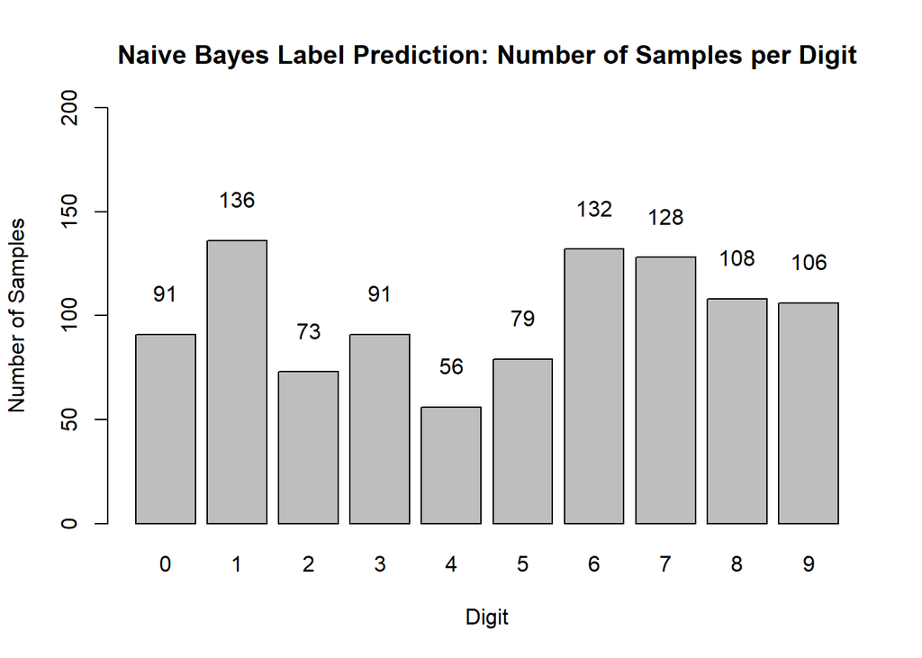

```r
labelTable <- table(predict_naiveBayes)
barPlot <- plot(predict_naiveBayes, main = "Naive Bayes Label Prediction: Number of Samples per Digit", ylim = c(0, 200), xlab = "Digit", ylab = "Number of Samples")
text(x = barPlot, y = labelTable+20, labels = labelTable)
```

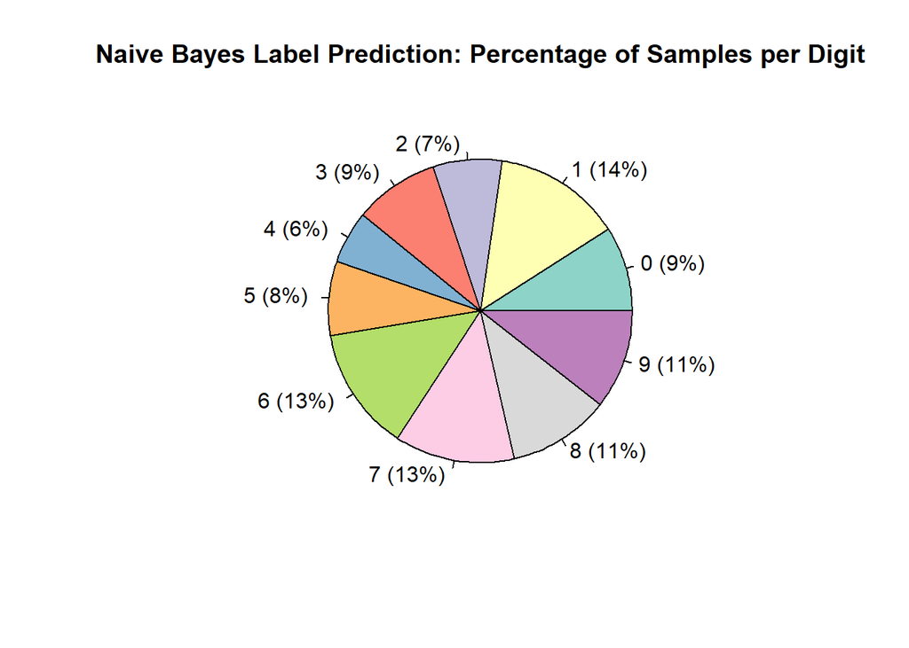

```r
colorPlot <- colorRampPalette(brewer.pal(10, "Set3"))
percent <- round(labelTable/sum(labelTable)*100)
labels <- paste0(row.names(labelTable), " (",percent,"%) ")
pie(labelTable, labels = labels, col = colorPlot(10), main = "Naive Bayes Label Prediction: Percentage of Samples per Digit")
```

## K-Nearest Neighbor Method

The K-Nearest Neighbor (kNN) model is now trained and tested on the same datasets used by the Naive Bayes model. Similar to the Naive Bayes model, the datasets for the kNN model also require preprocessing steps in addition to the general data preprocessing steps already done. Preprocessing is done on the both the training and testing datasets for the kNN model via the ‘predict()’ function and ‘pre_process’ variable, which scales and centers the data.

```r
data_train2 <- predict(pre_process, newdata = data_train)
data_test2 <- predict(pre_process, newdata = data_test)
```

```r
ctrl <- trainControl(method="repeatedcv", number = 8, repeats = 3)
time <- proc.time()
model_knn <- train(label ~ ., data = data_train2, method = "knn", trControl = ctrl, tuneGrid = data.frame(k = seq(1, 5)))
proc.time() - time
```

```
##    user  system elapsed
##   10.87    0.19   11.27
```

```r
print(model_knn)
```

```
## k-Nearest Neighbors
##
## 1122 samples
##  289 predictor
##   10 classes: '0', '1', '2', '3', '4', '5', '6', '7', '8', '9'
##
## No pre-processing
## Resampling: Cross-Validated (8 fold, repeated 3 times)
## Summary of sample sizes: 980, 981, 981, 983, 985, 980, ...
## Resampling results across tuning parameters:
##
##   k  Accuracy   Kappa
##   1  0.8837575  0.8706361
##   2  0.8546346  0.8382081
##   3  0.8699986  0.8552809
##   4  0.8682456  0.8533035
##   5  0.8697672  0.8550077
##
## Accuracy was used to select the optimal model using the largest value.
## The final value used for the model was k = 1.
```

Now that the kNN model has been trained, the model is used to predict the target attribute (‘label’) values on the testing dataset. A confusion matrix is then displayed, showing the number of correct and incorrect predictions made for each digit in the dataset. The matrix shows that an accuracy of 100% was achieved from using the kNN model to predict the labels of the testing dataset. A sensitivity analysis of the kNN model is also displayed, showing the accuracy (measured by repeated cross-validation) achieved for each k (number of neighbors) value.

```r
predict_knn <- predict(model_knn, newdata = data_test2)
confusionMatrix(predict_knn, data_test2$label)
```

```
## Confusion Matrix and Statistics
##
##           Reference
## Prediction  0  1  2  3  4  5  6  7  8  9
##          0 20  0  0  0  0  0  0  0  0  0
##          1  0 28  0  0  0  0  0  0  0  0
##          2  0  0 20  0  0  0  0  0  0  0
##          3  0  0  0 27  0  0  0  0  0  0
##          4  0  0  0  0 18  0  0  0  0  0
##          5  0  0  0  0  0 26  0  0  0  0
##          6  0  0  0  0  0  0 21  0  0  0
##          7  0  0  0  0  0  0  0 18  0  0
##          8  0  0  0  0  0  0  0  0 18  0
##          9  0  0  0  0  0  0  0  0  0 24
##
## Overall Statistics
##
##                Accuracy : 1
##                  95% CI : (0.9834, 1)
##     No Information Rate : 0.1273
##     P-Value [Acc > NIR] : < 2.2e-16
##
##                   Kappa : 1
##
##  Mcnemar's Test P-Value : NA
##
## Statistics by Class:
##
##                      Class: 0 Class: 1 Class: 2 Class: 3 Class: 4 Class: 5
## Sensitivity           1.00000   1.0000  1.00000   1.0000  1.00000   1.0000
## Specificity           1.00000   1.0000  1.00000   1.0000  1.00000   1.0000
## Pos Pred Value        1.00000   1.0000  1.00000   1.0000  1.00000   1.0000
## Neg Pred Value        1.00000   1.0000  1.00000   1.0000  1.00000   1.0000
## Prevalence            0.09091   0.1273  0.09091   0.1227  0.08182   0.1182
## Detection Rate        0.09091   0.1273  0.09091   0.1227  0.08182   0.1182
## Detection Prevalence  0.09091   0.1273  0.09091   0.1227  0.08182   0.1182
## Balanced Accuracy     1.00000   1.0000  1.00000   1.0000  1.00000   1.0000
##                      Class: 6 Class: 7 Class: 8 Class: 9
## Sensitivity           1.00000  1.00000  1.00000   1.0000
## Specificity           1.00000  1.00000  1.00000   1.0000
## Pos Pred Value        1.00000  1.00000  1.00000   1.0000
## Neg Pred Value        1.00000  1.00000  1.00000   1.0000
## Prevalence            0.09545  0.08182  0.08182   0.1091
## Detection Rate        0.09545  0.08182  0.08182   0.1091
## Detection Prevalence  0.09545  0.08182  0.08182   0.1091
## Balanced Accuracy     1.00000  1.00000  1.00000   1.0000
```

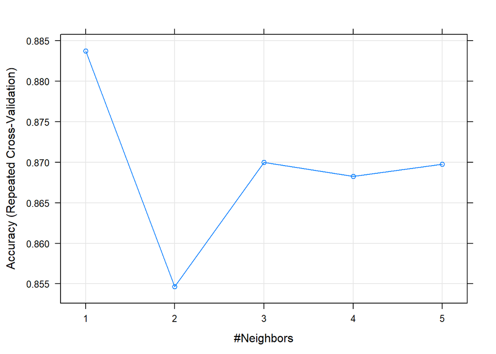

```r
plot(model_knn)
```

```r
data_test_unknown2 <- predict(pre_process, newdata = data_test_unknown)
predict_knn <- predict(model_knn, newdata = data_test_unknown2, type = "raw")
predict_knn
```

```
##   [1] 2 0 9 5 3 7 0 3 0 3 5 7 9 0 4 5 3 1 9 0 9 1 1 5 7 9 2 7 9 7 7 0 4 2 6
##  [36] 2 7 5 1 6 7 7 4 9 6 7 8 2 6 1 6 8 8 3 8 2 1 2 9 0 7 1 7 0 0 0 1 4 0 1
##  [71] 6 5 8 8 2 8 3 9 2 3 5 9 1 0 9 1 4 3 6 7 2 0 6 6 1 4 3 4 7 9 0 9 2 0 7
## [106] 7 0 5 0 9 0 0 4 7 1 7 1 1 3 3 3 7 2 8 6 3 8 7 1 4 3 5 6 0 0 0 3 1 5 0
## [141] 5 3 4 3 5 8 7 7 1 8 1 3 5 6 5 3 7 3 7 8 3 0 4 5 1 8 7 6 3 0 2 7 7 6 1
## [176] 3 7 7 1 2 4 8 5 2 4 9 2 1 6 0 6 1 4 4 6 0 9 7 6 9 1 9 0 9 9 0 8 4 6 2
## [211] 0 9 3 6 7 2 1 6 3 7 2 3 1 0 2 0 9 6 1 0 0 6 9 1 7 3 2 3 8 6 8 6 2 8 5
## [246] 5 9 8 1 1 9 7 1 3 8 4 5 1 4 5 6 3 3 5 7 0 6 8 3 1 6 0 6 3 9 5 1 5 8 4
## [281] 0 9 2 0 5 3 7 1 9 9 5 7 7 9 9 6 3 0 3 3 6 9 8 2 6 2 7 1 4 5 8 5 9 0 0
## [316] 3 9 4 1 8 4 1 1 9 8 4 3 1 5 3 6 3 1 3 0 4 0 0 6 0 6 3 1 8 6 0 6 5 3 3
## [351] 6 7 7 2 9 8 3 9 2 1 3 6 3 8 4 2 3 8 1 6 4 5 9 9 7 6 9 5 3 7 6 5 5 4 2
## [386] 6 2 1 3 9 1 7 9 9 6 1 1 1 7 3 9 7 6 1 1 1 9 3 5 6 5 0 4 1 2 3 1 1 3 5
## [421] 9 6 6 5 3 1 4 7 7 7 4 8 5 2 2 1 3 9 5 0 8 4 7 4 9 4 1 5 3 9 9 7 6 9 3
## [456] 9 2 3 1 6 1 7 5 0 5 1 7 4 9 1 1 4 9 5 6 0 1 3 1 0 4 8 1 2 7 9 4 8 3 7
## [491] 7 4 8 4 6 7 5 3 2 0 6 5 9 4 1 8 5 3 0 6 7 6 8 7 5 3 5 7 4 3 6 9 0 7 7
## [526] 1 0 1 1 7 0 5 3 8 3 5 6 5 7 3 0 2 8 2 0 3 0 9 2 1 1 3 0 5 0 0 7 5 6 2
## [561] 0 3 8 1 6 5 1 1 1 4 6 5 3 6 0 4 8 2 4 2 5 1 9 6 9 1 7 3 8 0 8 8 4 5 3
## [596] 6 6 6 0 3 1 1 7 1 6 2 8 5 6 9 7 4 3 3 2 4 7 0 0 9 8 5 9 9 0 8 1 3 6 7
## [631] 6 1 8 6 1 4 7 7 8 3 0 9 9 6 7 7 4 9 1 8 9 9 0 0 8 2 4 3 3 7 2 3 4 0 4
## [666] 8 1 3 3 6 3 4 4 3 3 7 7 5 6 0 6 9 8 9 1 3 4 6 9 9 7 6 0 1 8 4 3 9 8 8
## [701] 4 0 5 0 6 0 4 4 6 5 1 8 1 5 5 6 2 3 7 3 9 3 1 0 1 6 6 4 7 5 7 1 3 2 7
## [736] 7 1 6 1 5 4 4 3 4 3 9 0 7 8 6 9 9 4 4 1 4 7 1 1 7 7 0 4 0 4 0 0 5 1 8
## [771] 6 5 0 1 5 3 4 6 3 1 1 6 9 8 3 5 5 9 8 8 5 0 4 0 4 3 1 6 9 7 1 1 3 3 1
## [806] 9 9 6 9 1 5 9 2 8 2 4 0 9 7 8 3 0 5 0 1 9 0 4 5 2 8 0 5 4 3 9 6 1 3 3
## [841] 1 9 0 8 5 6 7 2 8 5 8 9 7 7 2 5 1 3 4 5 0 4 1 4 2 3 6 9 2 3 4 5 4 2 5
## [876] 8 1 1 0 1 4 9 1 1 2 7 1 5 4 9 1 7 6 0 4 2 9 9 1 1 5 3 5 7 9 7 3 3 2 7
## [911] 2 0 4 7 1 6 4 6 1 0 7 3 5 9 4 7 9 6 6 3 3 2 1 4 5 3 7 7 9 5 6 2 6 1 0
## [946] 9 3 2 9 2 6 7 5 2 3 1 8 3 6 2 7 9 4 0 7 5 1 8 7 5 3 2 9 6 7 0 3 0 7 4
## [981] 5 8 7 9 7 7 0 5 3 2 1 9 0 6 8 3 6 2 2
## Levels: 0 1 2 3 4 5 6 7 8 9
```

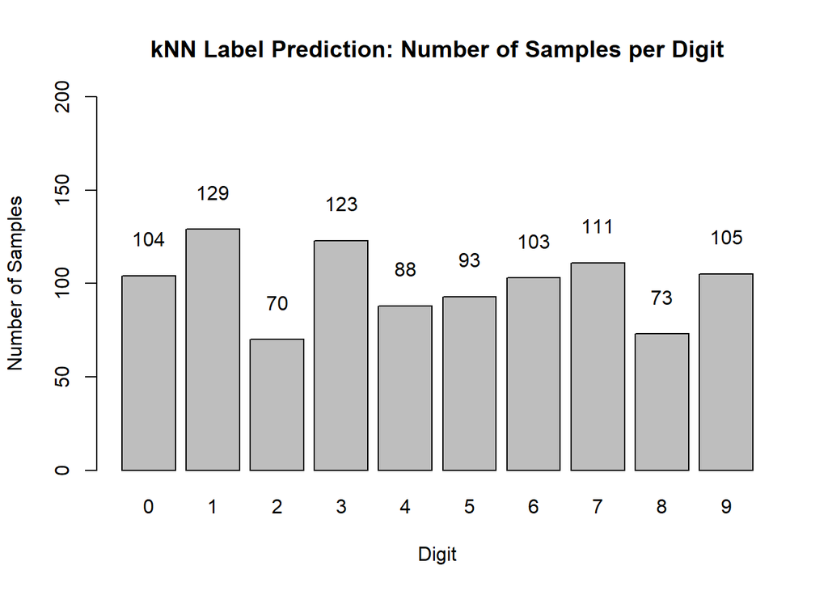

```r
labelTable <- table(predict_knn)
barPlot <- plot(predict_knn, main = "kNN Label Prediction: Number of Samples per Digit", ylim = c(0, 200), xlab = "Digit", ylab = "Number of Samples")
text(x = barPlot, y = labelTable+20, labels = labelTable)
```

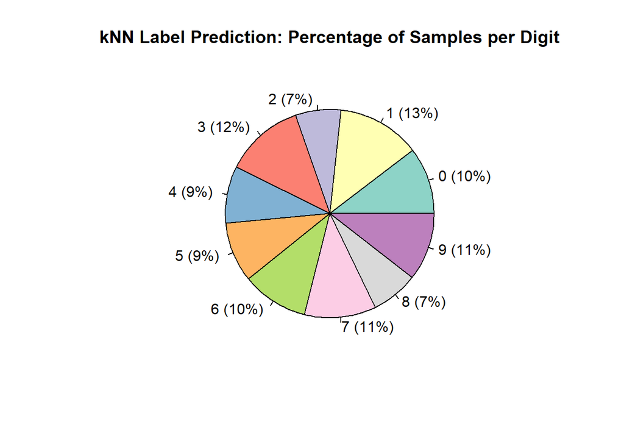

```r
colorPlot <- colorRampPalette(brewer.pal(10, "Set3"))
percent <- round(labelTable/sum(labelTable)*100)
labels <- paste0(row.names(labelTable), " (",percent,"%) ")
pie(labelTable, labels = labels, col = colorPlot(10), main = "kNN Label Prediction: Percentage of Samples per Digit")
```